# survey_results

### Questions

#### 1. What company type has the the highest career satisfaction rate for developers

#### 2. What company type has the the highest job satisfaction rate for developers

#### 3. What company types have the most developers working from home

#### 4. If job satisfaction for developers is attributed to Auditory Environment

```python
# Import required libraries
import pandas as pd
import numpy as np
import matplotlib.pyplot as plt
import seaborn as sb
%matplotlib inline
from matplotlib import cm

# Read in csv file
df = pd.read_csv('survey_results_public.csv')
```

```python
# Create a dataframe from only "Professional Developer" in the Professional column
developer_df = df[df['Professional'] == 'Professional developer']
```

#### Because my questions are based specifically on developers, I removed all data rows where the respondent did not identify as a developer

```python
# Create dataframes for all data we are reviewing

# Create a dataframe of developers and dropping any rows where CompanyType is NaN
developer_df = developer_df.dropna(subset = ['CompanyType'])

# Fill NaNs in the JobSatisfaction and CareerSatisfaction columns with the mean
developer_df['JobSatisfaction'].fillna(developer_df['JobSatisfaction'].mean(), inplace = True)
developer_df['CareerSatisfaction'].fillna(developer_df['CareerSatisfaction'].mean(), inplace = True)
# Convert columns to integers
developer_df['JobSatisfaction'] = developer_df['JobSatisfaction'].astype(int)
developer_df['CareerSatisfaction'] = developer_df['CareerSatisfaction'].astype(int)

# Create a dataframe for the auditory environment and removing NaNs
auditory_df = developer_df.dropna(subset = ['AuditoryEnvironment'])

# Create a datafram for how often a developer works from home
remote_work_df = developer_df.dropna(subset = ['HomeRemote'])
```

#### I created 3 dataframes for the different groups to answer the different questions. For my developer dataframe, I dropped all rows where the respondent did not select a company type. I decided to leave the answers, "I don't know", "I prefer not to say", and "Something else" because these answers may be valuable in the analysis. I did not want to remove too many rows, I decided to replace any NaNs with the mean values for both Job and Career Satisfaction. I then converted those responses to integers to assist with analysis.

#### For the auditory dataframe and remote work dataframe, I decided that I would drop any row where the respondent did not identify those variables.

```python
# Create a developer group by CompanyType and JobSatisfaction
developer_group = developer_df.groupby(['CompanyType'], as_index = False)['JobSatisfaction'].sum()
# Create a group of total count by CompanyType and JobSatisfaction
total_respondents_by_job_sat = developer_df.groupby(['CompanyType'], as_index = False)['JobSatisfaction'].count()
# Merge the two groups into a new DataFrame
developer_group_new = pd.merge(developer_group, total_respondents_by_job_sat, on = ['CompanyType'])
# Rename column names
developer_group_new = developer_group_new.rename({'JobSatisfaction_x': 'job_satisfaction_total', 'JobSatisfaction_y': 'total'}, axis = 1)
# Divide job_satisfaction_total by total to get percentage
developer_group_new['average'] = developer_group_new['job_satisfaction_total'] / developer_group_new['total']
# Sort the average values highest to lowest
developer_group_new = developer_group_new.sort_values('average', ascending = False)
```

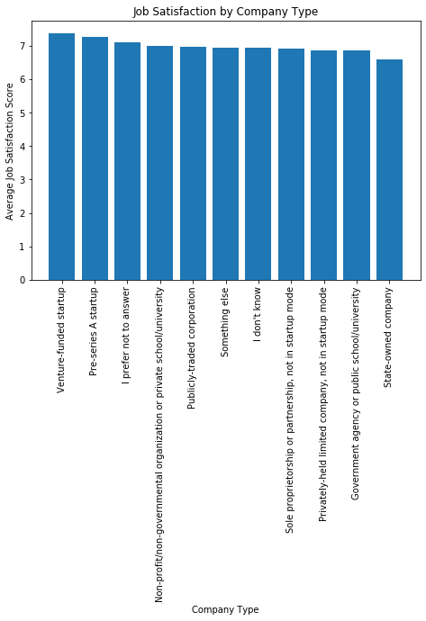

```python
# Bar chart of percentage of job satisfaction by company type
fig = plt.figure()
ax = fig.add_axes([0,0,1,1])
plt.xticks(rotation = 90)
company_type = developer_group_new['CompanyType']
average_satisfaction = developer_group_new['average']
plt.title('Job Satisfaction by Company Type')
plt.xlabel('Company Type')
plt.ylabel('Average Job Satisfaction Score')
ax.bar(company_type, average_satisfaction)
plt.show;
```

#### Here we can see that the company type that has the highest average Job Satisfaction are those developers that work for Venture-Funded Startups. Those devolopers that work for a state-owned company have the lowest Job Satisfaction.

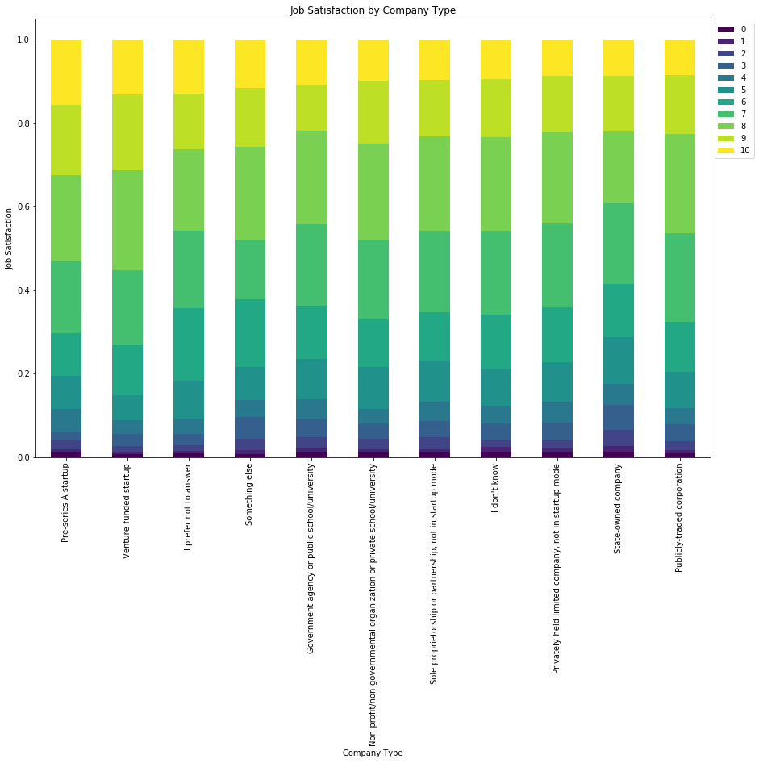

```python
#Create a new developer group by CompanyType, JobSatisfaction and Respondent
job_sat_df = developer_df.groupby(['CompanyType', 'JobSatisfaction'], as_index = False)['Respondent'].count()
#Calculate total number of respondents
total_respondents = developer_df['CompanyType'].value_counts()
# Calculate the percentage
job_sat_df['Percentage'] = job_sat_df.apply(lambda x: x['Respondent'] / total_respondents[x['CompanyType']], axis = 1)
# Change Job Satisfaction data type to a string
job_sat_df['JobSatisfaction'] = job_sat_df['JobSatisfaction'].astype(np.int64)
job_sat_df['JobSatisfaction'] = job_sat_df['JobSatisfaction'].apply(str)
# Create a pivot table to pull data from
job_sat = pd.pivot_table(job_sat_df, values = 'Percentage', index = 'CompanyType', columns = 'JobSatisfaction').sort_values('10', ascending = False)
job_sat = job_sat[['0', '1', '2', '3', '4', '5', '6', '7', '8', '9', '10']]


# Create a stacked bar chart of Job Satisfaction by Company Type
job_sat.plot(kind = 'bar', stacked = True, colormap = 'viridis', figsize = (15, 10))
plt.legend(loc = "upper left", bbox_to_anchor = (1, 1))
plt.xlabel('Company Type')
plt.ylabel('Job Satisfaction')
plt.title('Job Satisfaction by Company Type')
plt.show();
```

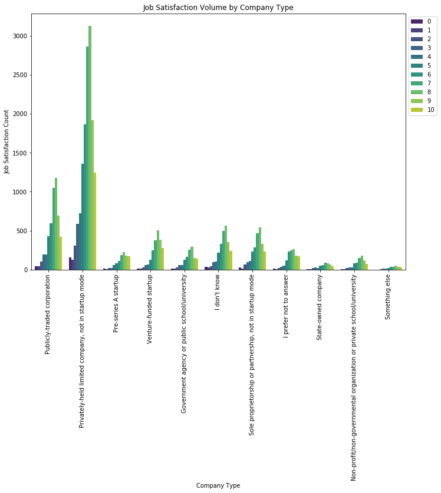

```python
# Create a bar chart showing distribution of answers of Job Satisfaction by Company Type
job_sat_order = [0, 1, 2, 3, 4, 5, 6, 7, 8, 9, 10]
plt.figure(figsize = [25, 8])

plt.subplot(1, 2, 1)
sb.countplot(data = developer_df, x = 'CompanyType', hue = 'JobSatisfaction',
             hue_order = job_sat_order, palette = 'viridis')
plt.xticks(rotation = 90)
plt.xlabel('Company Type')
plt.ylabel('Job Satisfaction Count')
plt.title('Job Satisfaction Volume by Company Type')
plt.legend(loc = "upper left", bbox_to_anchor = (1, 1));
```

#### We can see that the greatest number of respondents come from Privately Held Companies, however, developers that work for a Pre-Series A Startup are more likely to identify their Job Satisfaction as a 10.

```python
# Create a new developer group by CompanyType and CareerSatisfaction
developer_group_career = developer_df.groupby(['CompanyType'], as_index = False)['CareerSatisfaction'].sum()
# Create a group of total count by CompanyType and CareerSatisfaction
total_respondents_career = developer_df.groupby(['CompanyType'], as_index = False)['CareerSatisfaction'].count()
# Merge the two groups into a new DataFrame
developer_group_career_new = pd.merge(developer_group_career, total_respondents_career, on = ['CompanyType'])
# Rename column names
developer_group_career_new = developer_group_career_new.rename({'CareerSatisfaction_x': 'CareerSatisfaction_total', 'CareerSatisfaction_y': 'total'}, axis = 1)
# Divide job_satisfaction_total by total to get percentage
developer_group_career_new['average'] = developer_group_career_new['CareerSatisfaction_total'] / developer_group_career_new['total']
# Sort the average values highest to lowest
developer_group_career_new = developer_group_career_new.sort_values('average', ascending = False)
```

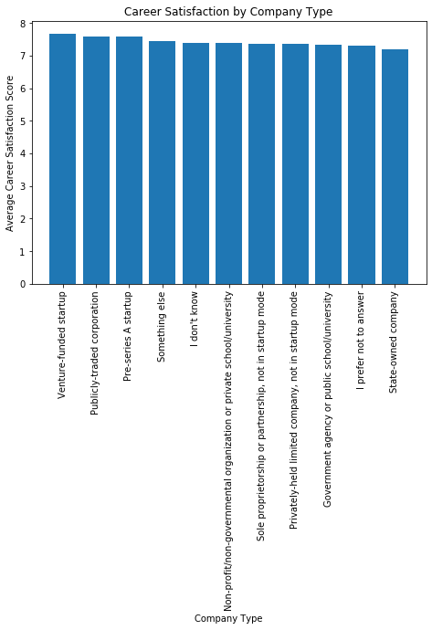

```python
# Bar chart of Career Satisfaction by Company Type
fig = plt.figure()
ax = fig.add_axes([0, 0, 1, 1])
plt.xticks(rotation = 90)
company_type_career = developer_group_career_new['CompanyType']
average_satisfaction_career = developer_group_career_new['average']
ax.bar(company_type_career, average_satisfaction_career)
plt.title('Career Satisfaction by Company Type')
plt.xlabel('Company Type')
plt.ylabel('Average Career Satisfaction Score')
plt.show();
```

#### Here again, we can see that the developers that have the highest Career Satisfaction work at Venture-funded start ups. Another point to note, Publicly Traded corporations jumped up the Career Satisfaction chart. Although developers that work for Pre-Series A startups enjoy higher Job Satisfaction, developers that work for Publically-traded corporations have higher career satisfactions than those that work for Pre-Series A startups. Also, devopers that work for State-owned companies have the lowest Career Satisfaction.

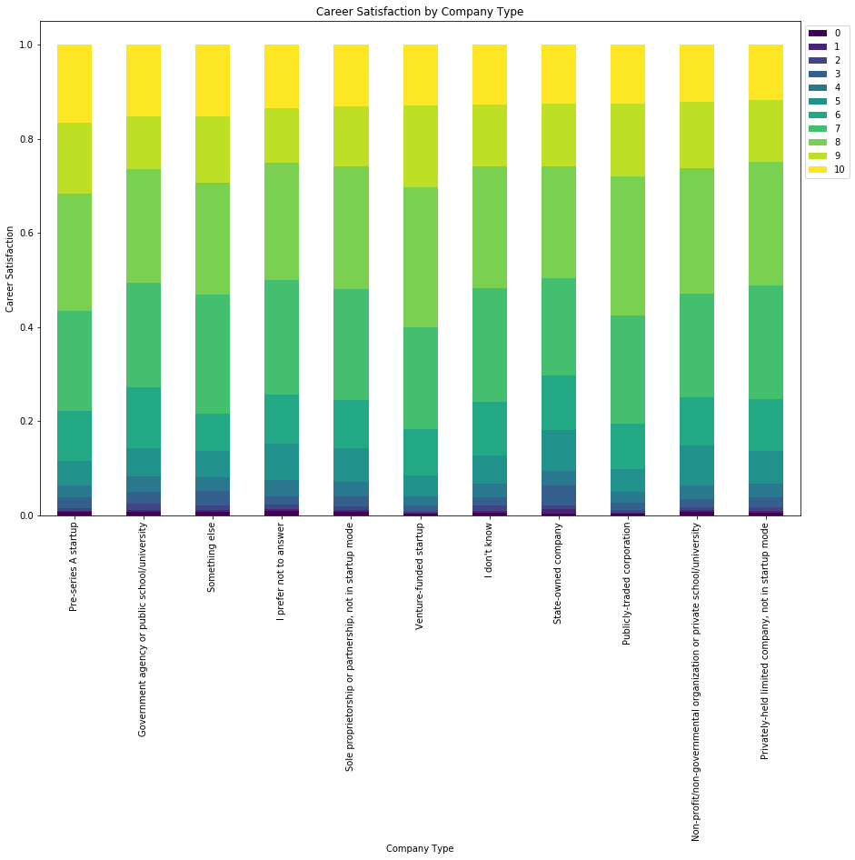

```python
# Create a new developer group by CompanyType, CareerSatisfaction and Respondent
car_sat_df = developer_df.groupby(['CompanyType', 'CareerSatisfaction'], as_index = False)['Respondent'].count()
# Calculate total number of respondents
total_respondents_per_company_type = developer_df['CompanyType'].value_counts()
# Calculate the percentage
car_sat_df['Percentage'] = car_sat_df.apply(lambda x: x['Respondent'] / total_respondents_per_company_type[x['CompanyType']], axis = 1)
# Change Job Satisfaction data type to a string
car_sat_df['CareerSatisfaction'] = car_sat_df['CareerSatisfaction'].astype(np.int64)
car_sat_df['CareerSatisfaction'] = car_sat_df['CareerSatisfaction'].apply(str)
# Create a pivot table to pull data from
car_sat = pd.pivot_table(car_sat_df, values = 'Percentage', index = 'CompanyType', columns = 'CareerSatisfaction').sort_values('10', ascending = False)
car_sat = car_sat[['0', '1', '2', '3', '4', '5', '6', '7', '8', '9', '10']]

# Create a stacked bar chart of Career Satisfaction by Company Type
car_sat.plot(kind = 'bar', stacked = True, colormap = 'viridis',figsize = (15, 10))
plt.legend(loc = "upper left", bbox_to_anchor = (1, 1))
plt.xlabel('Company Type')
plt.ylabel('Career Satisfaction')
plt.title('Career Satisfaction by Company Type')
plt.show();
```

###### Pre-Series A startup developers are more likely to identify Career Satisfaction as a 10, however, Venture-funded startups and Publically traded corporations are least likely to rate their Career Satisfaction as a 0 or 1.

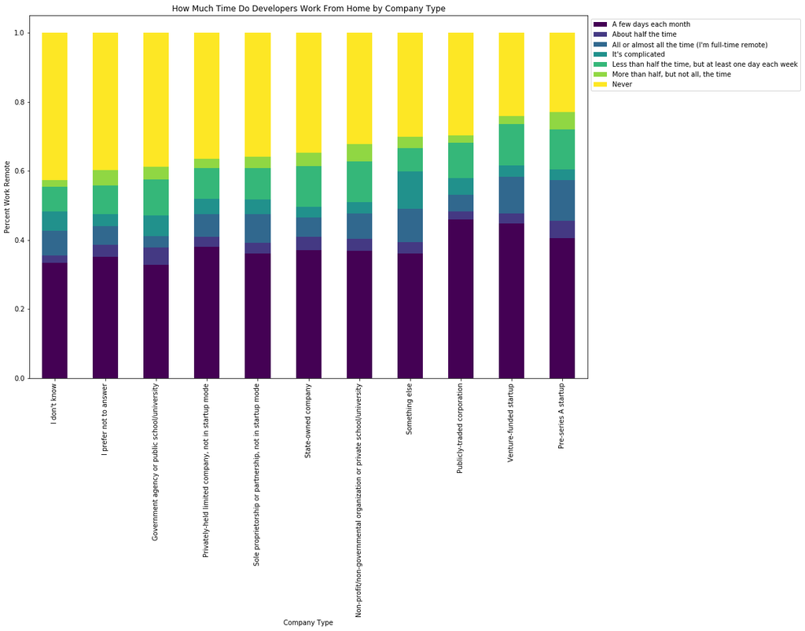

```python
# Create a new developer group by CompanyType, HomeRemote and Respondent
remote_df = remote_work_df.groupby(['CompanyType', 'HomeRemote'], as_index = False)['Respondent'].count()
# Calculate total number of respondents
total_respondents_remote = remote_work_df['CompanyType'].value_counts()
# Calculate the percentage
remote_df['Percentage'] = remote_df.apply(lambda x: x['Respondent'] / total_respondents_remote[x['CompanyType']], axis = 1)
# Create a pivot table to pull data from
remote_data = pd.pivot_table(remote_df, values = 'Percentage', index = 'CompanyType', columns = 'HomeRemote').sort_values('Never', ascending = False)

# Create a stacked bar chart of how much time a developer works from home by Company Type
remote_data.plot(kind = 'bar', stacked = True, colormap = 'viridis', figsize = (15, 10))
plt.legend(loc = "upper left", bbox_to_anchor = (1, 1))
plt.xlabel('Company Type')
plt.ylabel('Percent Work Remote')
plt.title('How Much Time Do Developers Work From Home by Company Type')
plt.show();
```

#### If you want to work from home at least some time, your best bet is to work for a Pre-Series A Startup. People that do not know what type of company that they work for or a unwilling to answer were least liketly to work from home at all. Government agencies were the least likely compnay type to allow employees to work from home.

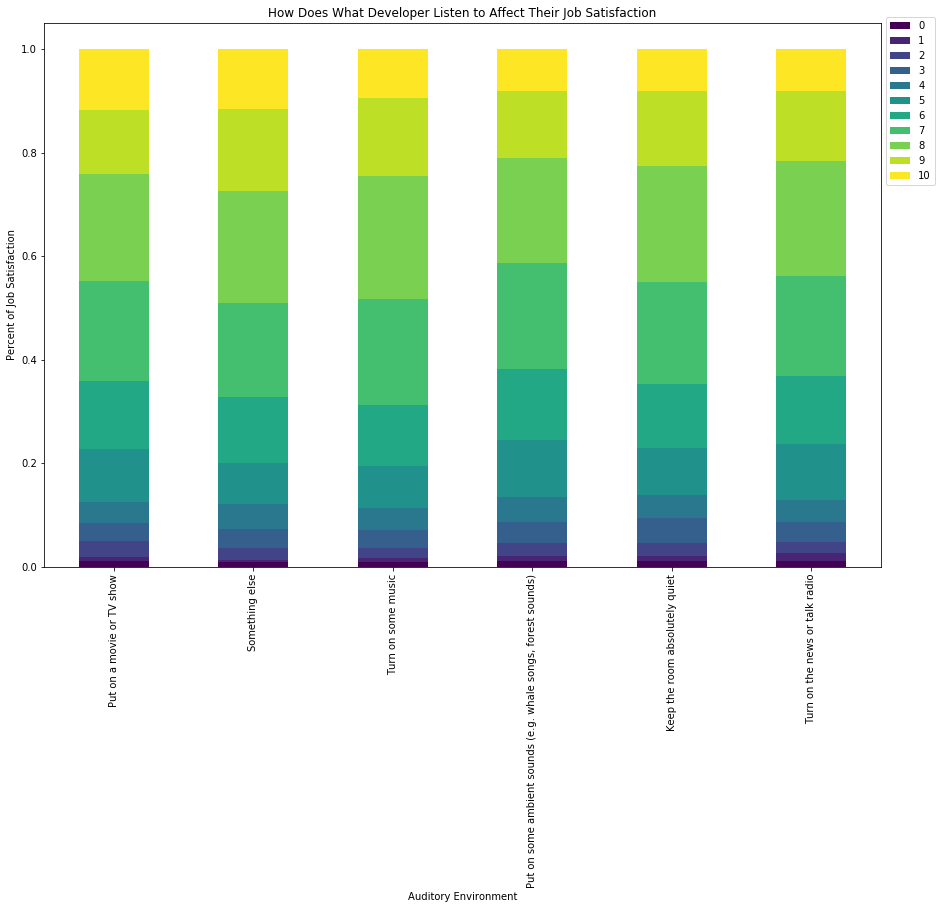

```python
# Create a new developer group by AuditoryEnvironment, JobSatisfaction and Respondent
aud_env = auditory_df.groupby(['AuditoryEnvironment', 'JobSatisfaction'], as_index = False)['Respondent'].count()
# Calculate total number of respondents
total_respondents_aud_env = auditory_df['AuditoryEnvironment'].value_counts()
# Calculate the percentage
aud_env['Percentage'] = aud_env.apply(lambda x: x['Respondent'] / total_respondents_aud_env[x['AuditoryEnvironment']], axis = 1)
# Change Job Satisfaction data type to a string
aud_env['JobSatisfaction'] = aud_env['JobSatisfaction'].astype(np.int64)
aud_env['JobSatisfaction'] = aud_env['JobSatisfaction'].apply(str)
# Create a pivot table to pull data from
aud_data = pd.pivot_table(aud_env, values = 'Percentage', index = 'AuditoryEnvironment', columns = 'JobSatisfaction').sort_values('10', ascending = False)
aud_data = aud_data[['0', '1', '2', '3', '4', '5', '6', '7', '8', '9', '10']]

# Create a stacked bar chart of how satisfied a developer is based on their auditory environment
aud_data.plot(kind = 'bar', stacked = True, colormap = 'viridis', figsize = (15, 10))
plt.legend(loc = "upper left", bbox_to_anchor = (1, 1.02))
plt.xlabel('Auditory Environment')
plt.ylabel('Percent of Job Satisfaction')
plt.title('How Does What Developer Listen to Affect Their Job Satisfaction')
plt.show();
```

```python
# Create a developer group by CompanyType and JobSatisfaction
auditory_group = auditory_df.groupby(['AuditoryEnvironment'], as_index = False)['JobSatisfaction'].sum()
# Create a group of total count by CompanyType and JobSatisfaction
total_respondents = auditory_df.groupby(['AuditoryEnvironment'], as_index = False)['JobSatisfaction'].count()
# Merge the two groups into a new DataFrame
developer_group_new = pd.merge(auditory_group, total_respondents, on = ['AuditoryEnvironment'])
# Rename column names
developer_group_new = developer_group_new.rename({'JobSatisfaction_x': 'job_satisfaction_total', 'JobSatisfaction_y': 'total'}, axis = 1)
# Divide job_satisfaction_total by total to get percentage
developer_group_new['average'] = developer_group_new['job_satisfaction_total'] / developer_group_new['total']
# Sort the average values highest to lowest
developer_group_new = developer_group_new.sort_values('average', ascending = False)
```

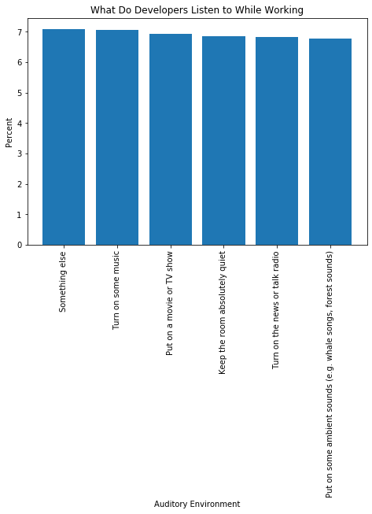

```python
# Create a bar chart showing the percentage of job satisfaction by Auditory Environment
fig = plt.figure()
ax = fig.add_axes([0, 0, 1, 1])
plt.xticks(rotation = 90)
aud_env_group = developer_group_new['AuditoryEnvironment']
average_satisfaction_job = developer_group_new['average']
ax.bar(aud_env_group, average_satisfaction_job)
plt.xlabel('Auditory Environment')
plt.ylabel('Percent')
plt.title('What Do Developers Listen to While Working')
plt.show();
```

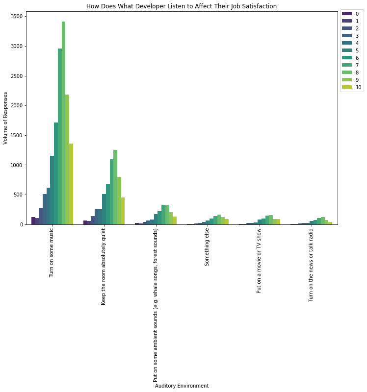

```python
# Create a bar chart showing distribution of answers of Job Satisfaction by Auditory Environment
job_sat_order = [0, 1, 2, 3, 4, 5, 6, 7, 8, 9, 10]
plt.figure(figsize = [25, 8])
plt.subplot(1, 2, 1)
sb.countplot(data = auditory_df, x = 'AuditoryEnvironment', hue = 'JobSatisfaction',
             hue_order = job_sat_order, palette = 'viridis')
plt.xticks(rotation = 90)
plt.xlabel('Auditory Environment')
plt.ylabel('Volume of Responses')
plt.title('How Does What Developer Listen to Affect Their Job Satisfaction')
plt.legend(loc = "upper left", bbox_to_anchor = (1,1.02));
```